# Opération Fourmis Public Inventory EDA

Tim Szewczyk

This notebook explores the Opération Fourmis public inventory data and summarises it across a few different potential variables of interest.

# Overview

The coordinates associated with the public inventory data are probably approximately accurate overall. My concern is that even relatively minor inaccuracies in the coordinates will cause a lot of misalignment between the local GIS layers and where the ants were actually collected. Even with ideal location recording methods and conditions, the GPS on devices like smartphones typically have a precision of about ± 5m. Before assigning habitat or land use categories to the collections, we need to know how reliable that is as a method, and constrain the questions and analyses accordingly.

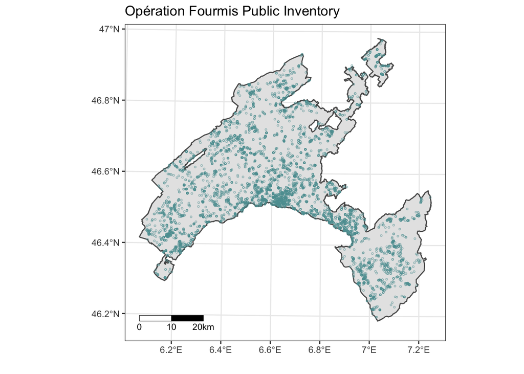

# Locational precision

## `GEOPRECISION`: Coordinate source

One concern with extracting local variables like habitat, land use, distance from the nearest road, or distance from the nearest building is that that requires a lot of confidence in the latitude and longitude associated with the point locations. The column `GEOPRECISION` indicates whether the location was extrapolated, corrected, or measured (or some combination).

Summary of geoprecision categorizations.

| GEOPRECISION | Tubes | Percent | Percent (non-NA) |
| --- | --- | --- | --- |
| mesuré | 6159 | 89.5% | 89.6% |
| extrapolé | 624 | 9.1% | 9.1% |
| extrapolé/corrigé | 44 | 0.6% | 0.6% |
| extrapolé mauvais | 17 | 0.2% | 0.2% |
| NA | 12 | 0.2% | - |
| mesuré/corrigé | 11 | 0.2% | 0.2% |
| extrapolé (base tube précédent) | 6 | 0.1% | 0.1% |
| extrapolé (église par défaut) | 5 | 0.1% | 0.1% |
| extrapolé (gare par défaut) | 4 | 0.1% | 0.1% |
| extrapolé/corrigé (église par défaut) | 1 | 0.0% | 0.0% |

The coordinates were mostly measured directly by the collector, and only a small proportion were extrapolated badly. In theory, we could assume that *mesuré*, *extrapolé*, *extrapolé/corrigé*, and *mesuré/corrigé* indicate that the coordinates can be used directly.

## Digits reported in decimal degrees

The number of reported digits is an estimate of precision for coordinates reported in decimal degrees, but not for the Swiss coordinate system which reports 6 digits no matter what. For latitude and longitude at the equator, an arc-degree corresponds with about 111km. At a [longitude of 46ºN](https://opendem.info/arc2meters.html), an arc-degree is 76.5km.

| Decimals | Precision (Lat.) | Precision (Lon.) |
| --- | --- | --- |
| 1 | ± 5500 m | ± 3825 m |
| 2 | ± 555 m | ± 383 m |
| 3 | ± 55.5 m | ± 38.3 m |
| 4 | ± 5.55 m | ± 3.83 m |
| 5 | ± 0.555 m | ± 0.383 m |
| 6 | ± 0.0555 m | ± 0.0383 m |

The reported digits can be used to set a minimum bound if, e.g., only 2 digits are reported, but typically devices will report many digits even if they are not justified. There were 3945 tubes (57.3%) reporting the coordinates in decimal degrees, with the rest using the 6-digit Swiss coordinates and no estimate of precision. The decimal degree coordinates include 686 tubes with coordinates extrapolated based on the reported locality. The reliability of the extrapolated coordinates for extracting local variables like habitat or land use type rely on a clear description of the habitat by the collector.

Decimal places for longitude (rows) and latitude (columns).

|  | 1 | 2 | 3 | 4 | 5 | 6 | 7 | 8 |
| --- | --- | --- | --- | --- | --- | --- | --- | --- |
| 2 | 0.0% | 0.0% | 0.0% | 0.2% | 0.1% | 0.0% | 0.0% | 0.7% |
| 3 | 0.0% | 0.1% | 0.9% | 0.9% | 0.1% | 0.0% | 0.1% | 0.7% |
| 4 | 0.0% | 0.0% | 1.0% | 11.0% | 1.0% | 0.1% | 0.3% | 1.0% |
| 5 | 0.0% | 0.1% | 0.2% | 1.8% | 10.1% | 2.5% | 0.2% | 0.8% |
| 6 | 0.0% | 0.0% | 0.1% | 0.3% | 2.6% | 27.6% | 1.7% | 0.6% |
| 7 | 0.0% | 0.0% | 0.0% | 0.1% | 0.3% | 0.9% | 4.7% | 0.4% |
| 8 | 0.0% | 0.0% | 0.0% | 0.0% | 0.0% | 0.0% | 0.4% | 0.4% |
| 9 | 0.0% | 0.2% | 0.2% | 1.4% | 0.5% | 0.3% | 0.3% | 23.3% |

Lat/Lon decimal accuracy (joint coarsest).

| Decimals | Tubes | Percent |
| --- | --- | --- |
| 1 | 1 | 0.0% |
| 2 | 52 | 1.3% |
| 3 | 165 | 4.2% |
| 4 | 670 | 17.0% |
| 5 | 669 | 17.0% |
| 6 | 1226 | 31.1% |
| 7 | 229 | 5.8% |
| 8 | 933 | 23.7% |

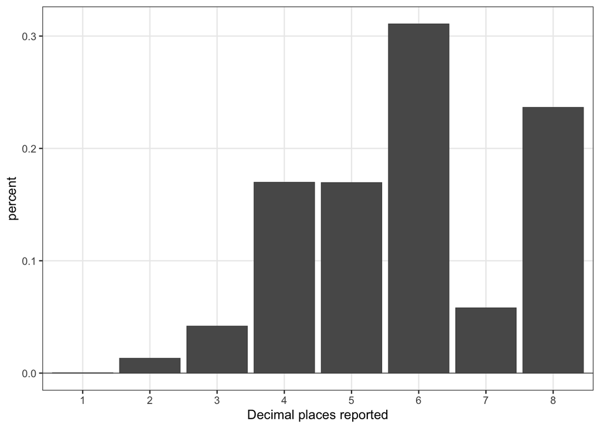

Typically, smartphones are accurate under good conditions to about [5m](https://www.gps.gov/systems/gps/performance/accuracy/) in radius, with worse performance around buildings, bridges, trees, etc. It therefore seems likely that coordinates with >5 decimal places are overestimating precision. More importantly, the 5.5% of locations with fewer than 4 should not be taken as-is with a high degree of confidence. Again, this metric isn’t possible with the locations recorded with the Swiss coordinate system (2938 tubes: 43%), but it seems reasonable that the distribution of precision would be roughly similar.

## Filtering

For extracting local conditions based on point locations, it seems reasonable to buffer all points with 5-10m, with the local habitat or land use type assigned as the dominant category within the buffer. The buffer should not affect distance to nearest road, aside from reducing most distances by a uniform amount and reducing points with distances less than the buffer radius to 0m.

It is also a good idea to remove tubes with `GEOPRECISION == "extrapolé mauvais"` and possibly `"extrapolé (base tube précédent)"`, `"extrapolé (église par défaut)"`, `"extrapolé (gare par défaut)"`, `"extrapolé/corrigé (église par défaut)"` as the uncertainty seems likely to be greater than 5-10m. Lastly, tubes with fewer than 3 decimals for the lat/lon coordinates should also be removed for the same reasons.

```r
geo_exclude <- c("extrapolé mauvais",
                 "extrapolé (base tube précédent)",
                 "extrapolé (église par défaut)",
                 "extrapolé (gare par défaut)",
                 "extrapolé/corrigé (église par défaut)")
pub_filt <- ant$pub %>%
  filter(!is.na(GEOPRECISION)) %>%
  filter(!GEOPRECISION %in% geo_exclude) %>%
  filter(is.na(LATITUDE) | nchar(LATITUDE) > 5) %>% # Swiss coords | Lat decimals
  filter(is.na(LONGITUDE) | nchar(LONGITUDE) > 4) # Swiss coords | Lon decimals
```

```r
pub.5m <- ant$pub %>% st_buffer(dist=5)
pub.10m <- ant$pub %>% st_buffer(dist=10)
```

# Habitat with locational uncertainty

## Habitat extraction: Points and buffers

Using the same habitat categories as the structured samples, we can calculate the habitat for each tube as the point location, dominant habitat within 5m, and dominant habitat within 10m.

```r
# Run spatial join one time only because of processing time
# Loading results of st_join(., lc)
lc_pt.join <- st_read(paste0(gis_dir, "opfo_public_lc_pts.shp")) %>%
  setNames(readRDS(paste0(gis_dir, "opfo_public_lc_NAMES.rds")))
lc_5m.join <- st_read(paste0(gis_dir, "opfo_public_lc_5m.shp")) %>%
  setNames(readRDS(paste0(gis_dir, "opfo_public_lc_NAMES.rds")))
lc_10m.join <- st_read(paste0(gis_dir, "opfo_public_lc_10m.shp")) %>%
  setNames(readRDS(paste0(gis_dir, "opfo_public_lc_NAMES.rds")))
```

We can assign the habitat type for each tube as either the habitat at the point location, ignoring uncertainty, or the dominant habitat within the 5m or 10m buffer. Larger buffers will obviously include more habitat categories, and samples collected along roads or edges would most likely be mis-categorized since those habitat types are unlikely to have the greatest coverage within a 5m or 10m radius. Conversely, even slight inaccuracies in the coordinates would result in mis-categorization of these samples based on the point locations. Assigning a habitat to each point with any degree of confidence is not trivial.

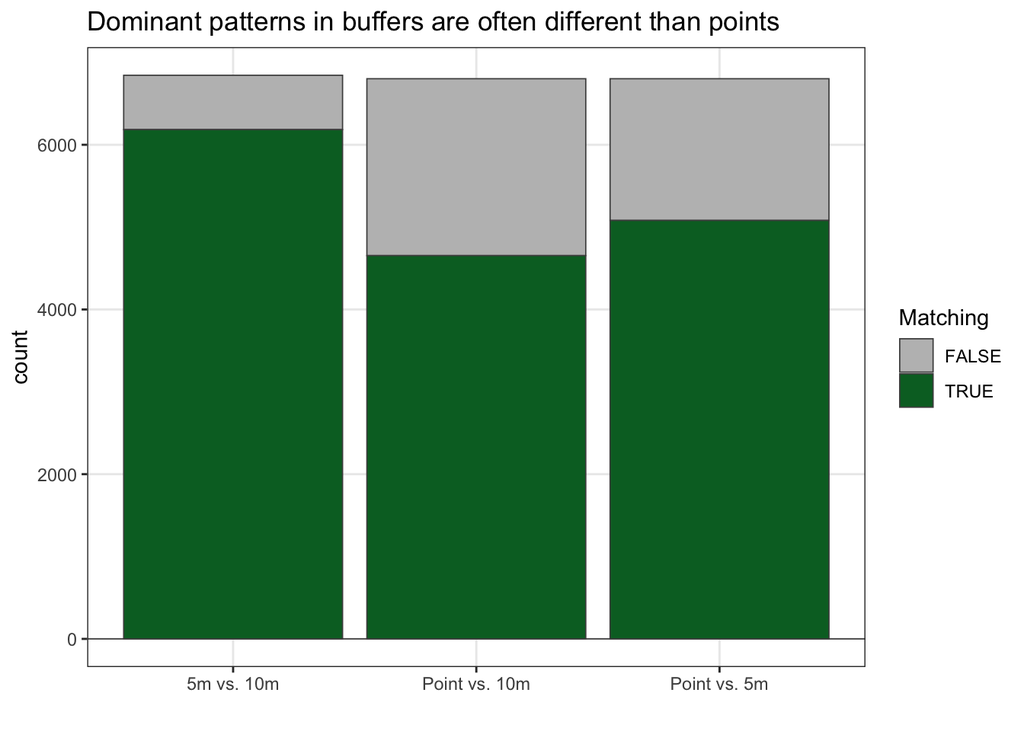

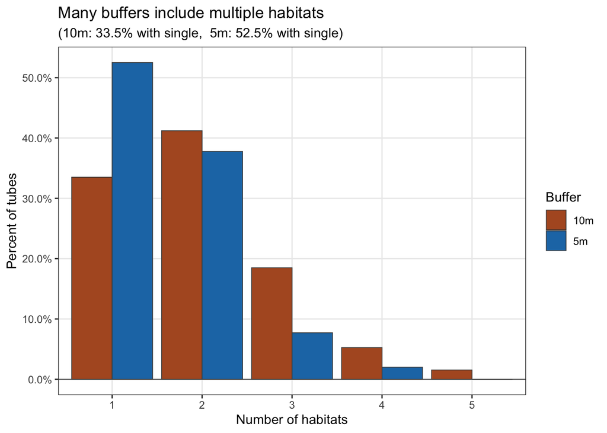

## `HABITAT`: Comparison of reported and extracted habitats

The public samples included a field for habitat, and 3393 tubes (49.3%) include a free-form entry. However, these were not standardized, and there were 1584 unique responses. They range from extremely precise about where the ant was captured to rather general. Some seem to describe the diameter of the tree where the ant was collected.

| HABITAT entries | count |
| --- | --- |
| "elles piquent" | 1 |
| [localité d'après coordonnées] | 10 |
| 1 fourmillière | 3 |
| 1 ouvrière Lasius jaune; 1 ouvrière Lasius emarginatus: sous 2 pierres différentes; 1 fondatrice Lasius sous mousse sur pierre | 3 |
| 1.2 diamètre | 2 |
| 1.2m haut | 1 |
| 1.3m diamètre | 1 |
| 1.5 m haut | 1 |
| 1.5m haut, 3m diamètre | 1 |
| 1.8m haut, 3m diamètre | 1 |

[output cut: 1575 more lines]

Searches for keywords could give an idea of how well the extracted habitat matches the stated habitat, at least for (mostly) unambiguous keywords.

### Forest

Forests are generally large habitat polygons, and most `HABITAT` descriptions including the word *forêt* should be describing tubes collected in forest habitat. Edges, borders, and clearings can be filtered out to look at a sort of ‘best case’ scenario.

```r
# Forest is maybe most straightforward, but it will also include edges and clearings
sum(grepl('[f,F]or.t', lc.df$HABITAT))
```

```
## [1] 421
```

```r
tabyl(grep('[f,F]or.t', lc.df$HABITAT, value=T)) %>% select(1,2) %>%
  setNames(c("HABITAT with for*t", "count")) %>% as_tibble
```

| HABITAT with for*t | count |
| --- | --- |
| 2 nids, sous la même pierre; en lisière de forêt | 5 |
| au sol; forêt | 1 |
| bois mort, forêt | 1 |
| bord chemin forêt | 2 |
| bord de foret | 1 |
| bord sentier foret | 1 |
| bordure foret | 1 |
| bordure paturage / foret | 1 |
| Chasse à vue sous branche; Sous-bois de forêt mixte, chênes, peupliers. Sous branche au sol | 1 |
| Chasse à vue sous écorce; Combe avec cours d'eau dans forêt de feuillu, humide à mésophile. Sous écorce de pin | 1 |

[output cut: 178 more lines]

```r
# HABITAT including for*t but excluding lisi*re, bord*, and clairi*re
HABITAT_foret <- grep('[f,F]or.t', unique(lc.df$HABITAT), value=T) %>%
  grep('lisi.re', ., value=T, invert=T) %>%
  grep('bord', ., value=T, invert=T) %>%
  grep('clari*re', ., value=T, invert=T)
# Forest habitat categorizations
foret.df <- full_join(filter(lc.df, HABITAT %in% HABITAT_foret) %>%
                        st_set_geometry(NULL) %>%
                        tabyl(lc.pt) %>% adorn_pct_formatting() %>%
                        select(lc.pt, n, percent) %>%
                        rename(Categorie=lc.pt, n_pt=n, pct_pt=percent),
                      filter(lc.df, HABITAT %in% HABITAT_foret) %>%
                        st_set_geometry(NULL) %>%
                        tabyl(lc.5m) %>% adorn_pct_formatting() %>%
                        select(lc.5m, n, percent) %>%
                        rename(Categorie=lc.5m, n_5m=n, pct_5m=percent),
                      by="Categorie") %>%
  full_join(.,
            filter(lc.df, HABITAT %in% HABITAT_foret) %>%
              st_set_geometry(NULL) %>%
              tabyl(lc.10m) %>% adorn_pct_formatting() %>%
              select(lc.10m, n, percent) %>%
              rename(Categorie=lc.10m, n_10m=n, pct_10m=percent),
            by="Categorie") %>%
  select(Categorie, contains("n_"), contains("pct_"))
knitr::kable(foret.df,
             caption="Habitat extractions for tubes with HABITAT reported as forest.")
```

Habitat extractions for tubes with HABITAT reported as forest.

| Categorie | n_pt | n_5m | n_10m | pct_pt | pct_5m | pct_10m |
| --- | --- | --- | --- | --- | --- | --- |
| Autre | 23 | 38 | 116 | 6.8% | 11.2% | 34.2% |
| CulturePerm | 1 | 1 | 1 | 0.3% | 0.3% | 0.3% |
| ForetConifere | 60 | 153 | 65 | 17.7% | 45.1% | 19.2% |
| ForetFeuillus | 45 | 62 | 74 | 13.3% | 18.3% | 21.8% |
| ForetMixe | 33 | 37 | 33 | 9.7% | 10.9% | 9.7% |
| lisiere | 18 | 2 | 2 | 5.3% | 0.6% | 0.6% |
| pierrier | 1 | 1 | 1 | 0.3% | 0.3% | 0.3% |
| transport | 117 | 1 | NA | 34.5% | 0.3% | NA |
| zalluviale | 7 | 8 | 8 | 2.1% | 2.4% | 2.4% |
| ZoneConstruite | 32 | 35 | 39 | 9.4% | 10.3% | 11.5% |
| NA | 2 | 1 | NA | 0.6% | 0.3% | NA |

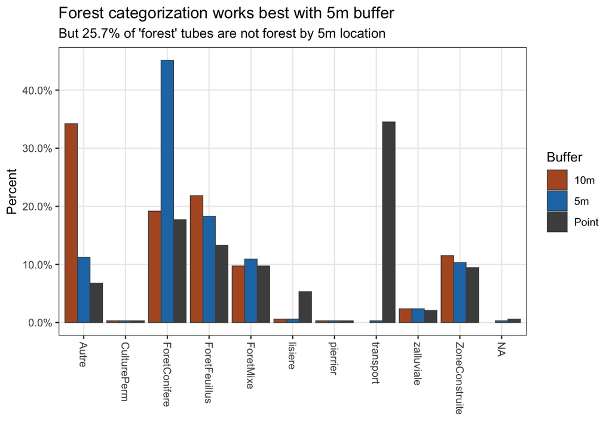

```r
foret.df %>% select(Categorie, contains("n_")) %>%
  rename(Point=n_pt, `5m`=n_5m, `10m`=n_10m) %>%
  adorn_percentages(denominator="col") %>%
  pivot_longer(2:4, names_to="Buffer", values_to="Prop") %>%
  ggplot(aes(Categorie, Prop, fill=Buffer)) +
  geom_bar(position="dodge", stat="identity", colour="grey30", size=0.3) +
  scale_y_continuous(labels=scales::percent_format()) +
  scale_fill_manual(values=buffer_col) +
  labs(x="", y="Percent",
       title="Forest categorization works best with 5m buffer",
       subtitle="But 25.7% of 'forest' tubes are not forest by 5m location") +
  theme(axis.text.x=element_text(angle=270, hjust=0, vjust=0.5))
```

The 10m buffer ends up including a lot more `Autre`, likely indicating that the points are near the forest edge even if they aren’t specified as such. The high proportion of point locations classified as `transport` could reflect that the ants were collected along a road in the forest, or that the location was collected after returning to the car.

### Lisière

The *a priori* expectation is that the point locations should be somewhat better for narrow habitat types like `lisière`. I would also expect poor performance across all methods, since inaccuracy in the point location is likely to move the point outside the habitat polygon, and buffers will include more non-target habitat types.

```r
sum(grepl('lisi.re', lc.df$HABITAT))
```

```
## [1] 207
```

```r
tabyl(grep('lisi.re', lc.df$HABITAT, value=T)) %>% select(1,2) %>%
  setNames(c("Edge HABITAT", "count")) %>% as_tibble
```

| Edge HABITAT | count |
| --- | --- |
| 2 nids, sous la même pierre; en lisière de forêt | 5 |
| aiguilles sapin lisière (nid 0.8 m diamètre) | 1 |
| aiguilles sapin lisière (nid 1 m diamètre) | 1 |
| aiguilles sapin lisière (nid 1.8 m diamètre) | 1 |
| Bas-marais, lande à sphaigne dans pâturage bovin et lisière de hêtraie-sapinière/pessière; Chasse à vue sous mousse | 2 |
| Chasse à vue sous pierre; Zone pionnière graveuleuse, chemin, lisière thermophile de forêt mixte | 1 |
| chemin lisière forêt | 1 |
| dôme 1.5m diamètre, lisière | 1 |
| dôme 1m diamètre, lisière | 1 |
| dôme aiguilles lisière | 1 |

[output cut: 85 more lines]

```r
# HABITAT including lisi*re or bord*
HABITAT_edge <- unique(grep('lisi.re', unique(lc.df$HABITAT), value=T))
# Edge habitat categorizations
edge.df <- full_join(filter(lc.df, HABITAT %in% HABITAT_edge) %>%
                        st_set_geometry(NULL) %>%
                        tabyl(lc.pt) %>% adorn_pct_formatting() %>%
                        select(lc.pt, n, percent) %>%
                        rename(Categorie=lc.pt, n_pt=n, pct_pt=percent),
                      filter(lc.df, HABITAT %in% HABITAT_edge) %>%
                        st_set_geometry(NULL) %>%
                        tabyl(lc.5m) %>% adorn_pct_formatting() %>%
                        select(lc.5m, n, percent) %>%
                        rename(Categorie=lc.5m, n_5m=n, pct_5m=percent),
                      by="Categorie") %>%
  full_join(.,
            filter(lc.df, HABITAT %in% HABITAT_edge) %>%
              st_set_geometry(NULL) %>%
              tabyl(lc.10m) %>% adorn_pct_formatting() %>%
              select(lc.10m, n, percent) %>%
              rename(Categorie=lc.10m, n_10m=n, pct_10m=percent),
            by="Categorie") %>%
  select(Categorie, contains("n_"), contains("pct_"))
knitr::kable(edge.df,
             caption="Habitat extractions for tubes with HABITAT reported as lisière")
```

Habitat extractions for tubes with HABITAT reported as lisière

| Categorie | n_pt | n_5m | n_10m | pct_pt | pct_5m | pct_10m |
| --- | --- | --- | --- | --- | --- | --- |
| Autre | 80 | 108 | 116 | 38.6% | 52.2% | 56.0% |
| ForetConifere | 12 | 20 | 17 | 5.8% | 9.7% | 8.2% |
| ForetFeuillus | 20 | 14 | 18 | 9.7% | 6.8% | 8.7% |
| ForetMixe | 15 | 28 | 21 | 7.2% | 13.5% | 10.1% |
| lisiere | 34 | 1 | NA | 16.4% | 0.5% | NA |
| marais | 3 | 3 | 3 | 1.4% | 1.4% | 1.4% |
| pierrier | 8 | 8 | 8 | 3.9% | 3.9% | 3.9% |
| PrairieSeche | 1 | 1 | 1 | 0.5% | 0.5% | 0.5% |
| transport | 21 | NA | NA | 10.1% | NA | NA |
| ZoneConstruite | 13 | 23 | 21 | 6.3% | 11.1% | 10.1% |
| zalluviale | NA | 1 | 1 | NA | 0.5% | 0.5% |
| CulturePerm | NA | NA | 1 | NA | NA | 0.5% |

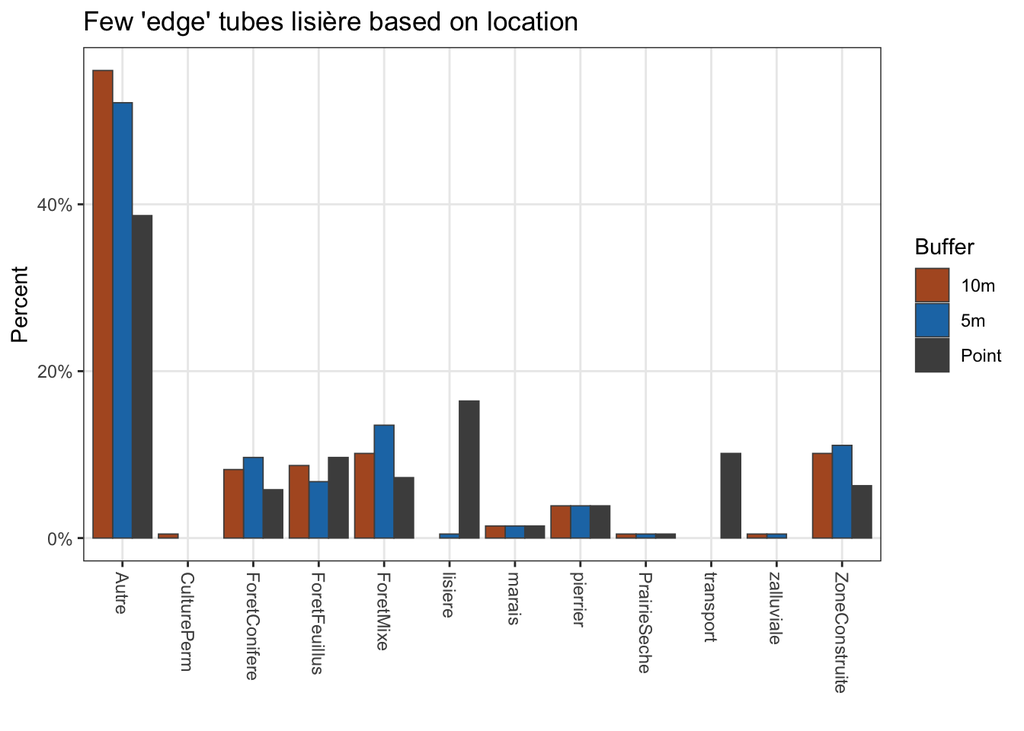

```r
edge.df %>% select(Categorie, contains("n_")) %>%
  rename(Point=n_pt, `5m`=n_5m, `10m`=n_10m) %>%
  adorn_percentages(denominator="col") %>%
  pivot_longer(2:4, names_to="Buffer", values_to="Prop") %>%
  ggplot(aes(Categorie, Prop, fill=Buffer)) +
  geom_bar(position="dodge", stat="identity", colour="grey30", size=0.3) +
  scale_y_continuous(labels=scales::percent_format()) +
  scale_fill_manual(values=buffer_col) +
  labs(x="", y="Percent",
       title="Few 'edge' tubes lisière based on location") +
  theme(axis.text.x=element_text(angle=270, hjust=0, vjust=0.5))
```

As expected, the point locations capture `lisière` best, but it is still only 16% of the tubes with *lisi.re* in the `HABITAT` description.